# Day 14: Cross-Validation — In-Class Activity (Solutions)

Is this college private? Choosing K with 5-fold CV

Instructor

```r
data(College)
College <- College %>%
  mutate(tuition = Outstate / 1000, undergrad = F.Undergrad / 1000)
k_values <- c(1, 3, 5, 11, 25, 51, 101, 201)
```

## Part 1: The Split’s Answer

### Task 1.1: One split

```r
set.seed(34)
train_rows <- sample(nrow(College), 500)
train <- College %>% slice(train_rows)
test  <- College %>% slice(-train_rows)

test_error <- rep(NA, length(k_values))

set.seed(1)   # knn() breaks rare ties at random; this makes them repeatable
for (i in 1:length(k_values)) {
  pred <- knn(train %>% select(tuition, undergrad),
              test %>% select(tuition, undergrad),
              cl = train$Private, k = k_values[i])
  test_error[i] <- mean(pred != test$Private)
}

split_results <- tibble(K = k_values, test_error = test_error)
split_results
```

```
## # A tibble: 8 × 2
##       K test_error
##   <dbl>      <dbl>
## 1     1     0.0650
## 2     3     0.0794
## 3     5     0.0830
## 4    11     0.0830
## 5    25     0.0866
## 6    51     0.0866
## 7   101     0.105
## 8   201     0.170
```

The split picks **K = 1**, with a test error of **6.5%**. K = 1 beats the next-best K by 4 colleges: a clear win on this split.

## Part 2: Cross-Validation for One K

### Task 2.1: Make the folds

```r
set.seed(122)
College <- College %>%
  mutate(fold = sample(rep(1:5, length.out = n())))
count(College, fold)
```

```
##   fold   n
## 1    1 156
## 2    2 156
## 3    3 155
## 4    4 155
## 5    5 155
```

### Task 2.2: The CV loop for K = 1

```r
errors <- rep(NA, 5)

set.seed(1)
for (f in 1:5) {
  train <- College %>% filter(fold != f)
  test  <- College %>% filter(fold == f)
  # The method: KNN with K = 1, the split's pick
  pred <- knn(train %>% select(tuition, undergrad),
              test %>% select(tuition, undergrad),
              cl = train$Private, k = 1)
  errors[f] <- mean(pred != test$Private)
}

errors
```

```
## [1] 0.10897436 0.10256410 0.07096774 0.09677419 0.08387097
```

```r
mean(errors)
```

```
## [1] 0.09263027
```

```r
sd(errors)
```

```
## [1] 0.01523953
```

```r
sd(errors) / sqrt(5)
```

```
## [1] 0.006815324
```

K = 1’s CV error is **9.3%**, with an SD across folds of **1.5%** and an SE of **0.7%**. The five folds range from 7.1% to 10.9%: same method, same K, only the test colleges change. The SD says how much one fold bounces around; the SE, 2.24 times smaller, says how much their average does.

The split reported 6.5% for K = 1, about 2.8 points lower than CV. That’s several SEs: the split’s 277 test colleges happened to suit K = 1 unusually well. CV tests every college once, so it can’t get lucky that way.

## Part 3: Choosing K with CV

### Task 3.1: Every K

```r
cv_error <- rep(NA, length(k_values))
se       <- rep(NA, length(k_values))

for (i in 1:length(k_values)) {
  errors <- rep(NA, 5)
  set.seed(1)
  for (f in 1:5) {
    train <- College %>% filter(fold != f)
    test  <- College %>% filter(fold == f)
    pred <- knn(train %>% select(tuition, undergrad),
                test %>% select(tuition, undergrad),
                cl = train$Private, k = k_values[i])
    errors[f] <- mean(pred != test$Private)
  }
  cv_error[i] <- mean(errors)
  se[i]       <- sd(errors) / sqrt(5)
}

cv_results <- tibble(K = k_values, cv_error = cv_error, se = se)
cv_results
```

```
## # A tibble: 8 × 3
##       K cv_error      se
##   <dbl>    <dbl>   <dbl>
## 1     1   0.0926 0.00682
## 2     3   0.0746 0.00688
## 3     5   0.0604 0.00769
## 4    11   0.0643 0.00831
## 5    25   0.0617 0.00848
## 6    51   0.0617 0.00513
## 7   101   0.0643 0.00452
## 8   201   0.109  0.00615
```

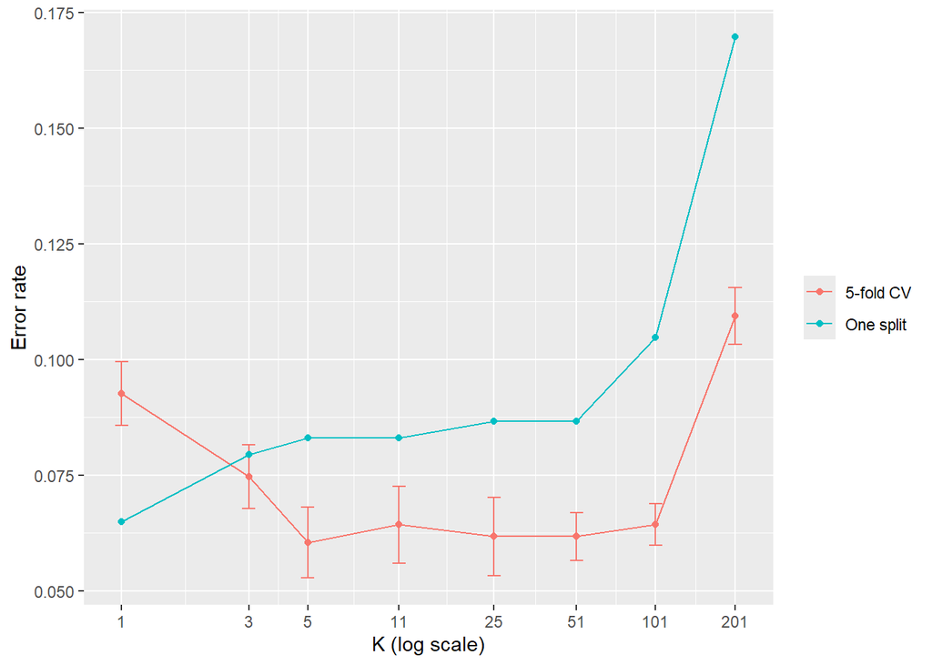

```r
both <- cv_results %>%
  left_join(split_results, by = "K") %>%            # one row per K, one column per method
  rename(`5-fold CV` = cv_error, `One split` = test_error) %>%
  pivot_longer(c(`5-fold CV`, `One split`), names_to = "method", values_to = "error") %>%
  mutate(se = if_else(method == "5-fold CV", se, NA))   # only CV has an SE

ggplot(both, aes(K, error, color = method)) +
  geom_errorbar(aes(ymin = error - se, ymax = error + se),
                width = 0.05, na.rm = TRUE) +
  geom_line() +
  geom_point() +
  scale_x_log10(breaks = k_values) +
  labs(x = "K (log scale)", y = "Error rate", color = NULL)
```

CV’s lowest error is **6.0% at K = 5**, not the split’s K = 1. In fact CV puts K = 1 at 9.3%, among the worst. On the plot, the split’s line dips at K = 1, right where the CV line is high; the CV line is nearly flat from K = 5 to K = 101.

But look at the SE. Every K in **5, 11, 25, 51, 101** has a CV error within one SE (0.8%) of the lowest; only K = 1, 3, 201 are clearly worse, and the split’s pick is one of them. Across that whole range the differences are smaller than the noise in the CV errors themselves, so the choice among them barely matters. CV’s real message is “anything from 5 to 101 works; avoid the extremes,” not “K = 5 is the answer.” (Change the fold seed and the lowest point moves around inside that range; see Bonus 1.)

To choose one, any K in the range is defensible. A middle value such as K = 25 or 51 is a safe pick: far from both extremes, so a different sample is unlikely to push it out of the good range.

Picking the lowest of several noisy test errors is too optimistic because each K’s test error is part signal, part luck. Keep the **lowest** of eight, and the winner is partly the K whose luck happened to go our way, so its error is biased low. That’s what happened to K = 1: trusting the split would have been wrong twice, the wrong K and an error 2.8 points too low (Part 2).

## Part 4: KNN or Logistic Regression?

### Task 4.1: Same folds, different method

```r
errors <- rep(NA, 5)

for (f in 1:5) {
  train <- College %>% filter(fold != f)
  test  <- College %>% filter(fold == f)
  # The method: logistic regression
  fit  <- glm(Private ~ tuition + undergrad, data = train, family = binomial)
  pred <- if_else(predict(fit, test, type = "response") > 0.5, "Yes", "No")
  errors[f] <- mean(pred != test$Private)
}

errors
```

```
## [1] 0.06410256 0.08974359 0.05161290 0.06451613 0.07096774
```

```r
mean(errors)
```

```
## [1] 0.06818859
```

```r
sd(errors) / sqrt(5)
```

```
## [1] 0.00623409
```

Logistic regression’s CV error is **6.8%**, with an SE of 0.6%. The best KNN is 6.0% (SE 0.8%), a gap of 0.8 points: about one SE, so borderline, not a clear win. And that’s the best KNN on a curve whose lowest point is partly luck, as Part 3 showed: K = 11, for example, is only 0.4 points better than logistic regression.

Since the gap is no bigger than the noise, put **logistic regression** on the website. It’s more stable, it’s small (three coefficients instead of the whole training set), and it explains itself: higher tuition and fewer undergraduates mean more likely private.

## Bonus

### Bonus 1: Another seed

```r
cv_knn_seed <- function(seed) {
  set.seed(seed)
  d <- College %>% mutate(fold = sample(rep(1:5, length.out = n())))
  cv_error <- rep(NA, length(k_values))
  se       <- rep(NA, length(k_values))
  for (i in 1:length(k_values)) {
    errors <- rep(NA, 5)
    set.seed(1)
    for (f in 1:5) {
      train <- d %>% filter(fold != f)
      test  <- d %>% filter(fold == f)
      pred <- knn(train %>% select(tuition, undergrad),
                  test %>% select(tuition, undergrad),
                  cl = train$Private, k = k_values[i])
      errors[f] <- mean(pred != test$Private)
    }
    cv_error[i] <- mean(errors)
    se[i]       <- sd(errors) / sqrt(5)
  }
  results <- tibble(K = k_values, cv_error = cv_error, se = se)
  best <- results %>% slice_min(cv_error, n = 1, with_ties = FALSE)
  close <- results %>% filter(cv_error <= best$cv_error + best$se)
  tibble(seed = seed, best_K = best$K, best_cv_error = best$cv_error,
         within_one_se = paste(close$K, collapse = ", "))
}

seeds_tab <- tibble()
for (s in c(122, 1, 2, 3, 4)) {
  seeds_tab <- bind_rows(seeds_tab, cv_knn_seed(s))
}
seeds_tab
```

```
## # A tibble: 5 × 4
##    seed best_K best_cv_error within_one_se
##   <dbl>  <dbl>         <dbl> <chr>
## 1   122      5        0.0604 5, 11, 25, 51, 101
## 2     1     25        0.0631 5, 11, 25, 51, 101
## 3     2     51        0.0630 5, 11, 25, 51, 101
## 4     3     11        0.0605 3, 5, 11, 25, 51, 101
## 5     4     25        0.0579 5, 11, 25, 51, 101
```

The lowest point moves: across these seeds CV picks K = 5, 25, 51, 11, 25. What stays the same is the **shape**: K = 5 through 101 are within one SE of the best on every seed, K = 1 and K = 201 are always clearly worse (K = 3 is borderline), and the best CV error stays between 5.8% and 6.3%. So CV is a reliable guide to the *range* of good K’s and to the error to expect, not to a single best K. When the curve is this flat, a single best K doesn’t exist.

### Bonus 2: Leave-one-out in one line

```r
X <- College %>% select(tuition, undergrad)

set.seed(1)
mean(knn.cv(X, cl = College$Private, k = 5) != College$Private)
```

```
## [1] 0.06563707
```

```r
mean(knn.cv(X, cl = College$Private, k = 11) != College$Private)
```

```
## [1] 0.06435006
```

```r
mean(knn.cv(X, cl = College$Private, k = 51) != College$Private)
```

```
## [1] 0.06692407
```

LOOCV gives 6.6%, 6.4%, 6.7% for K = 5, 11, and 51, against 5-fold’s 6.0%, 6.4%, 6.2%: all within 0.5 points, about one SE or less. LOOCV fits 777 times per K (one per college, each trained on the other 776), against 5 times for 5-fold CV. KNN is cheap enough not to notice; for slower methods, 5 or 10 folds give nearly the same answer for a fraction of the computing.

### Bonus 3: Which predictors?

```r
cv_logistic <- function(formula) {
  errors <- rep(NA, 5)
  for (f in 1:5) {
    train <- College %>% filter(fold != f)
    test  <- College %>% filter(fold == f)
    fit  <- glm(formula, data = train, family = binomial)
    pred <- if_else(predict(fit, test, type = "response") > 0.5, "Yes", "No")
    errors[f] <- mean(pred != test$Private)
  }
  tibble(cv_error = mean(errors), se = sd(errors) / sqrt(5))
}
```

```r
cv_logistic(Private ~ tuition)
```

```
## # A tibble: 1 × 2
##   cv_error     se
##      <dbl>  <dbl>
## 1    0.166 0.0162
```

```r
cv_logistic(Private ~ undergrad)
```

```
## # A tibble: 1 × 2
##   cv_error      se
##      <dbl>   <dbl>
## 1    0.140 0.00484
```

```r
cv_logistic(Private ~ tuition + undergrad + perc.alumni)
```

```
## # A tibble: 1 × 2
##   cv_error     se
##      <dbl>  <dbl>
## 1   0.0605 0.0101
```

```r
summary(glm(Private ~ tuition + undergrad + perc.alumni,
            data = College, family = binomial))
```

```
##
## Call:
## glm(formula = Private ~ tuition + undergrad + perc.alumni, family = binomial,
##     data = College)
##
## Coefficients:
##             Estimate Std. Error z value Pr(>|z|)
## (Intercept) -3.68408    0.54323  -6.782 1.19e-11 ***
## tuition      0.69158    0.07095   9.747  < 2e-16 ***
## undergrad   -0.57995    0.06011  -9.648  < 2e-16 ***
## perc.alumni  0.05001    0.01808   2.766  0.00567 **
## ---
## Signif. codes:  0 '***' 0.001 '**' 0.01 '*' 0.05 '.' 0.1 ' ' 1
##
## (Dispersion parameter for binomial family taken to be 1)
##
##     Null deviance: 910.75  on 776  degrees of freedom
## Residual deviance: 292.85  on 773  degrees of freedom
## AIC: 300.85
##
## Number of Fisher Scoring iterations: 7
```

| Model | CV error | SE |
| --- | --- | --- |
| tuition only | 16.6% | 1.6% |
| undergrad only | 14.0% | 0.5% |
| **tuition + undergrad** | **6.8%** | **0.6%** |
| + perc.alumni | 6.0% | 1.0% |

Dropping either predictor costs 7–10 points, many times the SE: a real difference. Tuition alone can’t tell a cheap small private college from a public one, and size alone can’t tell a big private university from a public one.

Adding `perc.alumni` changes the CV error by -0.8 points, inside one SE of the three-predictor model (1.0%): CV can’t tell it apart from no change, so the one-SE rule keeps the simpler model. That holds even though `perc.alumni` is significant (p = 0.0057). “Significant” means we’re confident the coefficient isn’t exactly zero: alumni giving does nudge the *probability* of being private. “Predicts better” means the nudge changes enough *labels* to cut the error on colleges the model hasn’t seen. Here the nudge is real but too small to show up clearly. To choose predictors for prediction, use the CV error, not p-values.